# Sessões, buscas e navegação na wikimedia

João Victor Mafra

O objeto principal da análise são as buscas e a navegação depois da busca. Criamos esses dados a partir dos dados originais da wikimedia em `/data/search_data.csv`.

Aqui, exploramos esses dados.

```r
buscas = read_csv(here::here("data/search_data.csv"))
names(buscas)[names(buscas) == "session_start_date"] <- "search_time"
```

## Investigando as principais variáveis do problema:

- num_clicks
- first_click
- results
- session_length

### Investigando a variável num_clicks:

Em geral, a maioria das buscas não tem nenhum clique em nenhum link como mostra a distribuição (Aproxidamente em 75% do casos).

A distribuição mostra apenas buscas com menos de 10 cliques, tendo em vista que em apenas 35 casos tiveram mais cliques que isso.

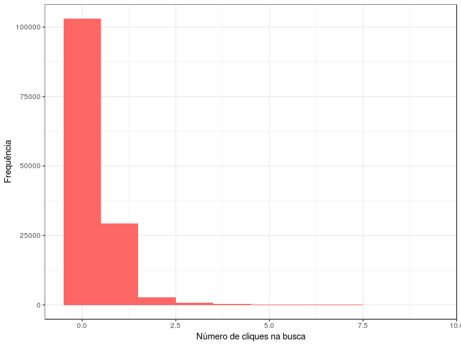

```r
buscas %>%
    filter(num_clicks < 10) %>%
    ggplot(aes(x = num_clicks)) +
    geom_histogram(bins = 10, fill = "#FF6666") +
    labs(x = "Número de cliques na busca", y = "Frequência")
```

```r
summary(buscas$num_clicks)
```

```
##    Min. 1st Qu.  Median    Mean 3rd Qu.    Max.
##  0.0000  0.0000  0.0000  0.2937  0.0000 36.0000
```

```r
nrow(buscas %>% filter(num_clicks >= 10))
```

```
## [1] 35
```

### Investigando a variável first_click:

Ela indica em qual link o usuário clicou dado que ele clicou em algum resultado da busca. O boxplot mostra que existem buscas com valores muito elevados e que não fazem muito sentido. O usuário fez 18 buscas em uma determinada sessão e cada busca retornou 20 resultados, mas o first_click mostra um valor exarcebado (4103 por exemplo). Todos esses outliers pertencem a essa mesma sessão, que será desconsiderada das futuras análises.

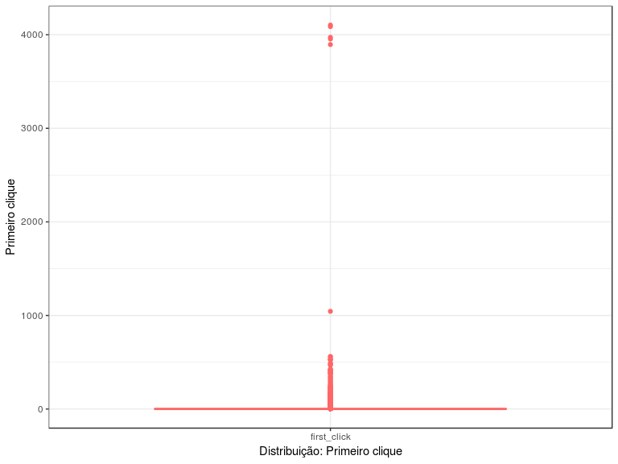

```r
buscas %>%
    ggplot(aes(x = "first_click", y = first_click)) +
    geom_boxplot(color = "#FF6666") +
    labs(x = "Distribuição: Primeiro clique", y = "Primeiro clique")
```

```r
summary(buscas$first_click)
```

```
##    Min. 1st Qu.  Median    Mean 3rd Qu.    Max.    NA's
##    1.00    1.00    1.00    3.92    2.00 4103.00  103040
```

```r
buscas <- buscas %>% filter(session_id != "5e0036c1b3bcd196")
```

### Investigando a variável results:

Podemos observar duas modas principais: 0 resultados e 20 resultados. Provavelmente esse parâmetro é fixo em cada busca. Mostra 20 resultados por página, ou 50 por página ou até 500. Caso não exista resultado, obviamente o número de resultados é 0, se houver apenas 1 por exemplo, o número de resultados é 1.

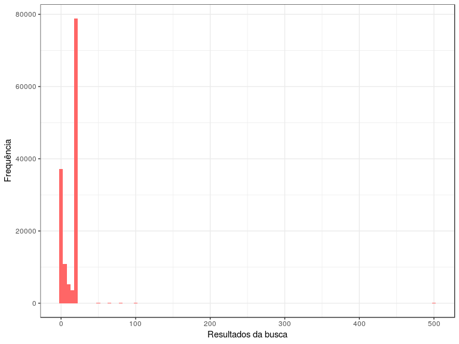

```r
buscas %>%
    ggplot(aes(x = results)) +
    geom_histogram(binwidth = 5, fill = "#FF6666") +
    labs(x = "Resultados da busca", y = "Frequência")
```

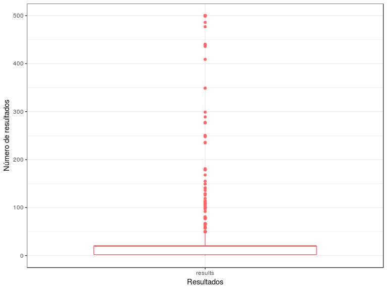

```r
buscas %>%
    ggplot(aes(x = "results", y = results)) +
    geom_boxplot(color = "#FF6666") +
    labs(x = "Resultados", y = "Número de resultados")
```

```r
summary(buscas$results)
```

```
##    Min. 1st Qu.  Median    Mean 3rd Qu.    Max.
##    0.00    2.00   20.00   13.21   20.00  500.00
```

### Investigando a variável session_length

Representa a duração da sessão. Em cada sessão podem ser feitas várias buscas.

Pelo boxplot vemos que a distribuição faz sentido com exceção de 2 pontos, que mostram durações de sessões bem acima do normal (6 dias e 2 dias). Eles impactam diretamente na média, pois como podemos ver a mediana é de apenas 15 segundos e a média de 153 segundos. Essas duas sessões também serão desconsideradas das análises futuras.

O histograma considera apenas sessões com durações menores que 50 minutos. Apenas 110 das 67950 sessões possuem duração acima disso. Temos uma moda em durações muito pequenas (A mediana é de apenas 15 segundos) e outra moda em um valor próximo de 8 minutos de duração.

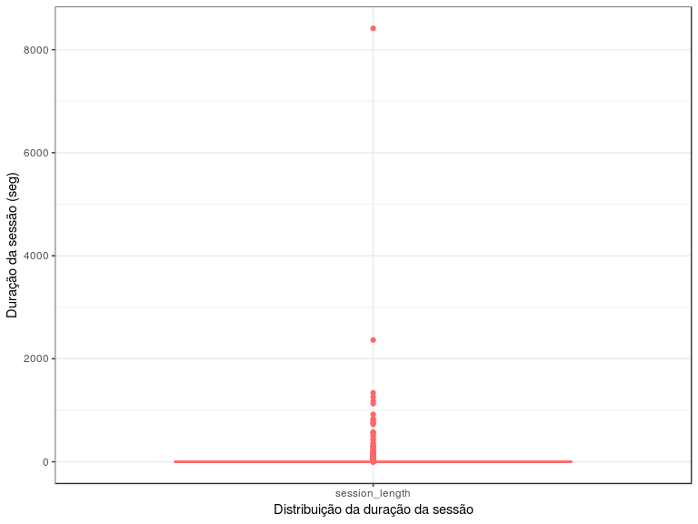

```r
buscas.por.sessao <- buscas %>% group_by(session_id) %>%
    summarise(session_length = first(session_length),
              search_time = first(search_time),
              group = first(group),
              sum_clicks = sum(num_clicks),
              sum_results = sum(results),
              total_searches = n())

buscas.por.sessao %>%
    ggplot(aes(x = "session_length", y = session_length/60)) +
    geom_boxplot(color = "#FF6666") +
    labs(x = "Distribuição da duração da sessão", y = "Duração da sessão (seg)")
```

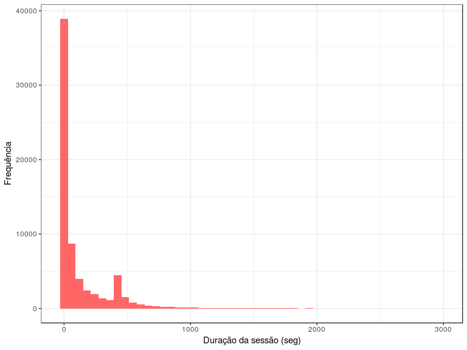

```r
buscas.por.sessao %>%
    filter(session_length < 3000) %>%
    ggplot(aes(x = session_length)) +
    geom_histogram(fill = "#FF6666", bins = 50) +
    labs(x = "Duração da sessão (seg)", y = "Frequência")
```

```r
nrow(buscas.por.sessao %>% filter(session_length >= 3000))
```

```
## [1] 110
```

```r
summary(buscas.por.sessao$session_length)
```

```
##     Min.  1st Qu.   Median     Mean  3rd Qu.     Max.
##      0.0      0.0     15.0    153.4    138.0 504900.0
```

```r
buscas <- buscas %>% filter(session_id != "8cf57f4f99f96220" & session_id != "e52d0c1117fc07eb")

buscas.por.sessao <- buscas.por.sessao %>% filter(session_id != "8cf57f4f99f96220" & session_id != "e52d0c1117fc07eb")
```

Dado que as variáveis a serem usadas foram analisadas e algumas sessões foram desconsideradas, vamos responder às perguntas de fato.

## What is our daily overall clickthrough rate? How does it vary between the groups?

Vamos medir a taxa de clique como sendo o número de sessões em que tivemos ao menos um clique dividido pelo total de sessões.

O grupo A possui um clickthrough rate próximo dos 70% para todos os dias, número bem acima do grupo B, que mostra até alguma evolução diária mas não ultrapassa os 20%.

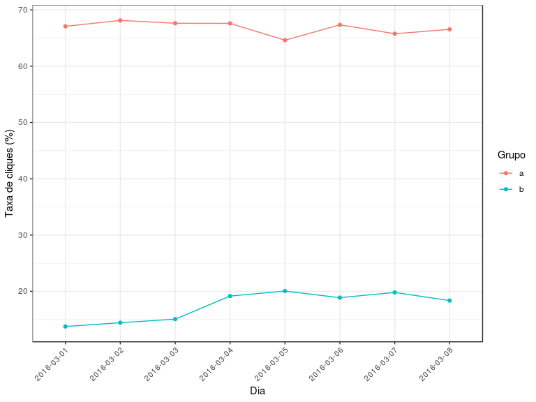

```r
buscas.agrupado.por.dia <- buscas.por.sessao %>%
    group_by(date = substr(search_time, 1, 10), group) %>%
    summarise(rate = sum(sum_clicks > 0)/n())

ggplot(buscas.agrupado.por.dia, aes(x = date, y = 100*rate, group = group, color = group)) +
    geom_point() +
    geom_line() +
    labs(x = "Dia", y = "Taxa de cliques (%)", color = "Grupo") +
    theme(plot.title = element_text(hjust = 0.5), axis.text.x = element_text(hjust = 1, angle = 45))
```

## Which results do people tend to try first? How does it change day-to-day?

Serão consideradas apenas as buscas em que o usuário clicou em algum resultado. Dado que ele clicou, qual link foi o primeiro clicado?

Inicialmente temos a distribuição da variável através de um histograma que considera apenas buscas cujo primeiro clique é menor que 25. Apenas 283 buscas das 136.203 tiveram um primeiro clique com valor maior ou igual a 25. Como esperado, o gráfico mostra que na maioria dos casos o usuário clica no primeiro link (ou nos primeiros links) da busca, tendo em vista que o 75-percentil é o segundo link.

A média pode ser impactada por valores extremos e a mediana é 1 para todos os dias e grupos. Por isso, será calculado também o 95-percentil, que indica que em 95% dos casos o primeiro link clicado está abaixo daquele valor.

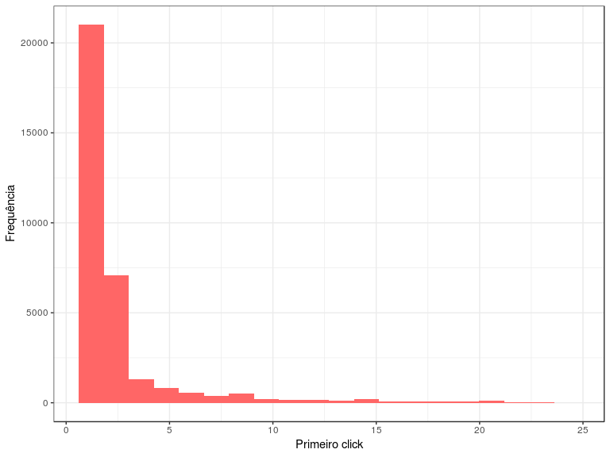

```r
buscas %>%
    filter(first_click < 25) %>%
    ggplot(aes(x = first_click)) +
    geom_histogram(fill = "#FF6666", bins = 20) +
    labs(x = "Primeiro click", y = "Frequência")
```

```r
nrow(buscas %>% filter(first_click >= 25))
```

```
## [1] 283
```

```r
summary(buscas$first_click)
```

```
##    Min. 1st Qu.  Median    Mean 3rd Qu.    Max.    NA's
##    1.00    1.00    1.00    3.32    2.00 1044.00  103022
```

```r
buscas.agrupado.por.dia.first.click <- buscas %>% na.omit(first_click)
buscas.agrupado.por.dia.first.click <- buscas.agrupado.por.dia.first.click %>%
    group_by(date = substr(search_time, 1, 10), group) %>%
    summarise(first_click_mean = mean(first_click),
              first_click_median = median(first_click),
              percentil = quantile(first_click, c(.95)),
              total = n())
```

O primeiro gráfico mostra a média do primeiro clique. O Grupo B é mais bem comportado, e em média o primeiro clique é no link 2. Isso se mantém ao longo dos dias. Para o Grupo A temos uma variação bem maior dos dados ao longo dos dias, com uma média bem maior em geral. Existe um dia cujo o primeiro clique médio foi no 9º link, um valor muito acima dos demais dias.

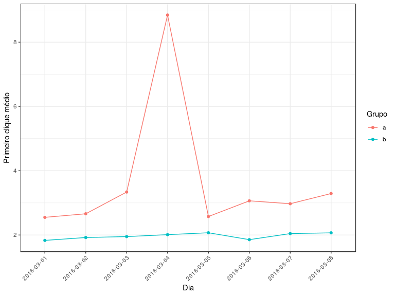

```r
ggplot(buscas.agrupado.por.dia.first.click, aes(x = date, y = first_click_mean, group = group, color = group)) +
    geom_point() +
    geom_line() +
    labs(x = "Dia", y = "Primeiro clique médio", color = "Grupo") +
    theme(plot.title = element_text(hjust = 0.5), axis.text.x = element_text(hjust = 1, angle = 45))
```

Agora temos o gráfico representando o 95-percentil do primeiro clique ao longo dos dias. Como esperado devido à visualização anterior, o 95-percentil do Grupo A é maior no geral.

Grupo A: Em geral, 95% dos “primeiro cliques” estão abaixo do 10º link, com um pico dia 04/03, em que o 95-percentil está no 14º link.

Grupo B: Em geral, 95% dos “primeiro cliques” estão abaixo do 6º link, atigindo seu maior valor no último dia, quando o 95-percentil está no 7º link.

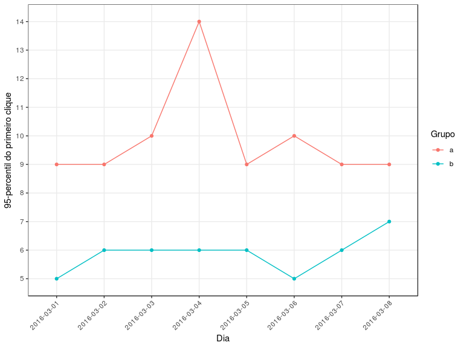

```r
ggplot(buscas.agrupado.por.dia.first.click, aes(x = date, y = percentil, group = group, color = group)) +
    geom_point() +
    geom_line() +
    scale_y_discrete(limits = c(5:14)) +
    labs(x = "Dia", y = "95-percentil do primeiro clique", color = "Grupo") +
    theme(plot.title = element_text(hjust = 0.5), axis.text.x = element_text(hjust = 1, angle = 45))
```

## What is our daily overall zero results rate? How does it vary between the groups?

Essa variável representa o número de buscas em que não foi obtido nenhum resultado dividido pelo total de buscas.

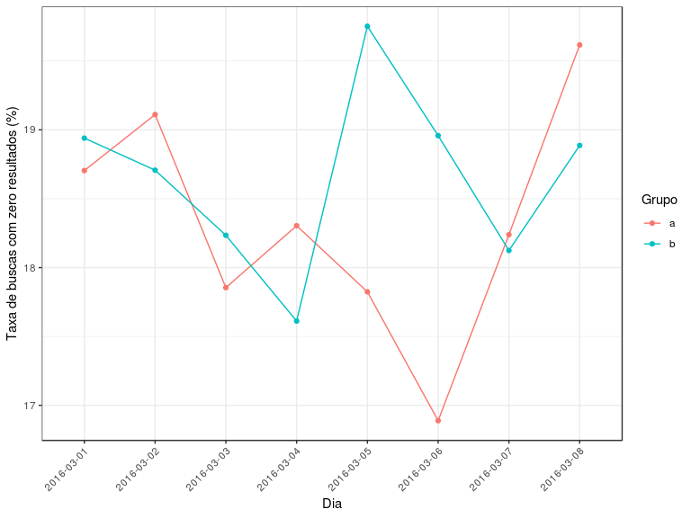

```r
buscas.agrupado.por.dia.zero.results <- buscas %>%
    group_by(date = substr(search_time, 1, 10), group) %>%
    summarise(zero_results_rate = sum(results == 0)/n())

ggplot(buscas.agrupado.por.dia.zero.results, aes(x = date, y = 100 * zero_results_rate, group = group, color = group)) +
    geom_point() +
    geom_line() +
    labs(x = "Dia", y = "Taxa de buscas com zero resultados (%)", color = "Grupo") +
    theme(plot.title = element_text(hjust = 0.5), axis.text.x = element_text(hjust = 1, angle = 45))
```

## Let session length be approximately the time between the first event and the last event in a session. Choose a variable from the dataset and describe its relationship to session length. Visualize the relationship.

```r
buscas.por.sessao.filtrado <- buscas.por.sessao %>% select(session_length, group, sum_clicks, sum_results, total_searches)
```

### Duração da sessão x Número de cliques

Será investigado se existe alguma relação entre a duração da sessão e o número totais de cliques que foram dados na mesma. Espera-se que exista já que de forma intuitiva espera-se quanto mais tempo uma pessoa passe numa sessão mais vezes ela clique nas buscas que são feitas.

Como temos muitos pontos concentrados nas mesmas regiões, será usado o geom_hex, que concentra os pontos de uma região em um hexágono só, facilitando a visualização. A tonalidade indica a quantidade de pontos concentrados naquela área.

Além disso, o eixo x (que representação a duração da sessão), será mostrado em escala de log por causa de algumas durações muito altas.

Como podemos ver, temos certa tendência de aumento no número de cliques quando a sessão dura mais. Apesar disso, na grande maioria dos casos o número de cliques ainda é muito pequeno independente da duração da sessão.

Calculando os coeficientes de correlação usando dois métodos temos:

Pearson: Mede se existe uma correlação linear entre as variáveis. O valor obtido de apenas 0.17 confirma o que diz o gráfico, de que até existe uma relação, mas ela não é linerar.

Spearman: Mede se existe alguma relação monótona entre as variáveis, seja ela linear ou não. O valor obtido de 0.71 mostra que existe uma correlação alta e positiva entre as duas variáveis, conforme esperado.

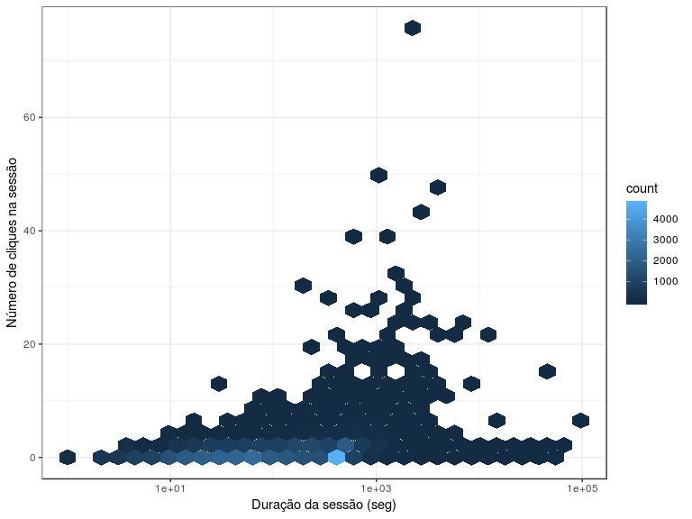

```r
buscas.por.sessao.filtrado %>%
    ggplot(aes(x = session_length, y = sum_clicks)) +
    geom_hex() +
    scale_x_log10() +
    labs(x = "Duração da sessão (seg)", y = "Número de cliques na sessão")
```

```r
correlacoes.clicks <- buscas.por.sessao.filtrado %>%
    summarise(cor_pearson = cor(session_length, sum_clicks, method = "pearson"),
              cor_spearman = cor(session_length, sum_clicks, method = "spearman"))

correlacoes.clicks
```

| cor_pearson | cor_spearman |
| --- | --- |
| 0.1756292 | 0.7147595 |

### Duração da sessão x Número de buscas feitas

Será investigado se existe alguma relação entre a duração da sessão e o número totais de buscas que foram feitas na mesma. Espera-se que exista já que de forma intuitiva espera-se quanto mais tempo uma pessoa passe numa sessão mais pesquisas ela faça.

Assim como no caso anterior, temos certa tendência de aumento no número de buscas quando a sessão dura mais, mas essa relação não é linear

Calculando os coeficientes de correlação usando os mesmos dois métodos temos:

Pearson: O valor obtido de apenas 0.16 confirma o que diz o gráfico, de que até existe uma relação, mas ela não é linerar.

Spearman: O valor obtido de 0.59 mostra que existe uma correlação positiva entre as duas variáveis, mas ela não é tão alta assim, apesar de estar mais próximo do 1 que do 0.

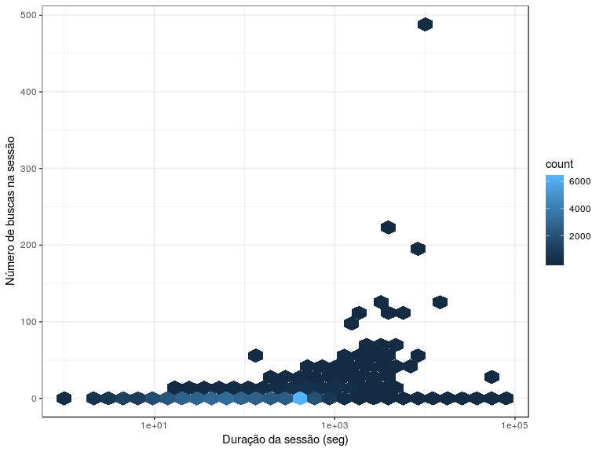

```r
buscas.por.sessao.filtrado %>%
    ggplot(aes(x = session_length, y = total_searches)) +
    geom_hex() +
    scale_x_log10() +
    labs(x = "Duração da sessão (seg)", y = "Número de buscas na sessão")
```

```r
correlacoes.buscas <- buscas.por.sessao.filtrado %>%
    summarise(cor_pearson = cor(session_length, total_searches, method = "pearson"),
              cor_spearman = cor(session_length, total_searches, method = "spearman"))

correlacoes.buscas
```

| cor_pearson | cor_spearman |
| --- | --- |
| 0.1678971 | 0.5971171 |